# Regras de Associação

1 Teoria

1.0.1 Exemplo de Regras

1.0.1.1 Cálculo do Suporte e Confiança

2 Estudo de Caso 1

2.0.1 Simulando Transações de Compras

2.0.2 Instalando o pacote "arules"

2.0.3 Criando uma base simulada

2.0.4 Convertendo a base para trasações

2.0.5 Extraindo as regras associadas

2.0.6 Inspecionando as regras

3 Estudo de Caso 2

3.0.1 Carregando a base de dados de transações

3.0.2 Definição das variáveis

3.0.3 Geração de Regras

3.0.4 Filtrando Regras

3.0.5 Segmentando Regras

3.0.6 Inspecionando Regras

4 Estudo de Caso 3

5 Estudo de Caso 4

# Teoria

| TID | Items |
| --- | --- |
| 1 | pão, leite |
| 2 | pão, fralda, cerveja, ovos |
| 3 | leite, fralda, cerveja, coca |
| 4 | pão, leite, fralda, cerveja |
| 5 | pão, leite, fralda, coca |

### Exemplo de Regras

| ID | Regras | Suporte & Confiança |
| --- | --- | --- |
| 1 | {leite,fralda} →{cerveja} | (s=0.4, c=0.67) |
| 2 | {leite,cerveja} →{fralda} | (s=0.4, c=1.0) |
| 3 | {fralda,cerveja} →{leite} | (s=0.4, c=0.67) |
| 4 | {cerveja} →{leite,fralda} | (s=0.4, c=0.67) |
| 5 | {fralda} →{leite,cerveja} | (s=0.4, c=0.5) |
| 6 | {leite} →{fralda,cerveja} | (s=0.4, c=0.5 |

Regras de associação – Uma expressão da forma X->Y, onde X e Y são conjuntos de itens

Exemplo: {Milk, Diaper} →{Beer}

##### Métricas de avaliação das regra

Suporte (X->Y) = número de registros contendo X e Y / Total de registros

O cálculo da taxa de confiança é calculada como a razão entre o número de registros contendo X e Y e o número de registros contendo X:

Confiança (X->Y) = Número de registros contendo X e Y / Número de registros contendo X

#### Cálculo do Suporte e Confiança

**Regra 1:**

- Suporte(R1) =Freq({leite,fralda,cerveja})/ Tot(T)= 2/5 = 0,4 e
- Confiança (R1)= Freq({leite,fralda,cerveja})/ Freq({leite, fralda}) = 2/3 = 0,67

**Regra 2:**

- Suporte(R1) =Freq({leite,cerveja,fralda})/ Tot(T)= 2/5 = 0,4 e
- Confiança (R1)= Freq({leite,cerveja,fralda})/ Freq({leite, cerveja}) = 2/2 = 1

# Estudo de Caso 1

### Simulando Transações de Compras

### Instalando o pacote "arules"

```r
install.packages('arules', repos='http://cran.us.r-project.org')
```

Caso o pacote acima já esteja instalado basta carrega-lo

```r
library(arules)
```

### Criando uma base simulada

```r
df <- read.table(header=T, text="ID     milk    bread   butter  beer    diapers
1   T   T   F   F   F
2   F   F   T   F   F
3   F   F   F   T   T
4   T   T   T   F   F
5   F   T   F   F   F")
```

```r
df
```

|  | ID | milk | bread | butter | beer | diapers |
| --- | --- | --- | --- | --- | --- | --- |
| 1 | 1 | 1 | 1 | 0 | 0 | 0 |
| 2 | 2 | 0 | 0 | 1 | 0 | 0 |
| 3 | 3 | 0 | 0 | 0 | 1 | 1 |
| 4 | 4 | 1 | 1 | 1 | 0 | 0 |
| 5 | 5 | 0 | 1 | 0 | 0 | 0 |

### Convertendo a base para trasações

```r
trans <- as(df[, -1], "transactions")
```

### Extraindo as regras associadas

```r
regras <- apriori(trans, list(supp = 0.01, conf = 0.5, minlen = 2))
```

```
Apriori

Parameter specification:
 confidence minval smax arem  aval originalSupport maxtime support minlen
        0.5    0.1    1 none FALSE            TRUE       5    0.01      2
 maxlen target   ext
     10  rules FALSE

Algorithmic control:
 filter tree heap memopt load sort verbose
    0.1 TRUE TRUE  FALSE TRUE    2    TRUE

Absolute minimum support count: 0

set item appearances ...[0 item(s)] done [0.00s].
set transactions ...[5 item(s), 5 transaction(s)] done [0.00s].
sorting and recoding items ... [5 item(s)] done [0.00s].
creating transaction tree ... done [0.00s].
checking subsets of size 1 2 3 done [0.00s].
writing ... [10 rule(s)] done [0.00s].
creating S4 object  ... done [0.00s].
```

Número de regras obtidas durabte a operação anterior

```r
regras
```

```
set of 10 rules
```

### Inspecionando as regras

```r
inspect(head(regras, n = 3, by = "support")) #apresentando 3 regras filtradas pela coluna "support"
```

```
    lhs        rhs       support confidence lift
[1] {milk}  => {bread}   0.4     1.0000000  1.666667
[2] {bread} => {milk}    0.4     0.6666667  1.666667
[3] {beer}  => {diapers} 0.2     1.0000000  5.000000
```

Ampliando a lista de regras

```r
print(cbind(as(regras, "data.frame")), digits=2)
```

```
                      rules support confidence lift
1       {beer} => {diapers}     0.2       1.00 5.00
2       {diapers} => {beer}     0.2       1.00 5.00
3        {butter} => {milk}     0.2       0.50 1.25
4        {milk} => {butter}     0.2       0.50 1.25
5       {butter} => {bread}     0.2       0.50 0.83
6         {milk} => {bread}     0.4       1.00 1.67
7         {bread} => {milk}     0.4       0.67 1.67
8  {milk,butter} => {bread}     0.2       1.00 1.67
9  {bread,butter} => {milk}     0.2       1.00 2.50
10 {milk,bread} => {butter}     0.2       0.50 1.25
```

Perceba que todos que compram cerveja compram fraldas. Todos que compram fraldas compram cervejas. E 50% dos que compram manteiga compram leite.

# Estudo de Caso 2

O conjunto de dados Adult contém os dados preparados como transações para uso com o pacote arules.

### Carregando a base de dados de transações

```r
data("Adult")
```

### Definição das variáveis

data set contains a data frame with 48842 observations on the following 15 variables.

age a numeric vector.

workclass a factor with levels Federal-gov, Local-gov, Never-worked, Private, Self-emp-inc, Self-emp-not-inc, State-gov, and Without-pay.

education an ordered factor with levels Preschool < 1st-4th < 5th-6th < 7th-8th < 9th < 10th < 11th < 12th < HS-grad < Prof-school < Assoc-acdm < Assoc-voc < Some-college < Bachelors < Masters < Doctorate.

education-num a numeric vector.

marital-status a factor with levels Divorced, Married-AF-spouse, Married-civ-spouse, Married-spouse-absent, Never-married, Separated, and Widowed.

occupation a factor with levels Adm-clerical, Armed-Forces, Craft-repair, Exec-managerial, Farming-fishing, Handlers-cleaners, Machine-op-inspct, Other-service, Priv-house-serv, Prof-specialty, Protective-serv, Sales, Tech-support, and Transport-moving.

relationship a factor with levels Husband, Not-in-family, Other-relative, Own-child, Unmarried, and Wife.

race a factor with levels Amer-Indian-Eskimo, Asian-Pac-Islander, Black, Other, and White.

sex a factor with levels Female and Male.

capital-gain a numeric vector.

capital-loss a numeric vector.

fnlwgt a numeric vector.

hours-per-week a numeric vector.

native-country a factor with levels Cambodia, Canada, China, Columbia, Cuba, Dominican-Republic, Ecuador, El-Salvador, England, France, Germany, Greece, Guatemala, Haiti, Holand-Netherlands, Honduras, Hong, Hungary, India, Iran, Ireland, Italy, Jamaica, Japan, Laos, Mexico, Nicaragua, Outlying-US(Guam-USVI-etc), Peru, Philippines, Poland, Portugal, Puerto-Rico, Scotland, South, Taiwan, Thailand, Trinadad&Tobago, United-States, Vietnam, and Yugoslavia.

income an ordered factor with levels small < large.

### Geração de Regras

Podemos agora produzir as regras de associação com o uso da função apriori.

```r
regras <- apriori(Adult, parameter = list(support = 0.4, conf=0.5))
```

```
Apriori

Parameter specification:
 confidence minval smax arem  aval originalSupport maxtime support minlen
        0.5    0.1    1 none FALSE            TRUE       5     0.4      1
 maxlen target   ext
     10  rules FALSE

Algorithmic control:
 filter tree heap memopt load sort verbose
    0.1 TRUE TRUE  FALSE TRUE    2    TRUE

Absolute minimum support count: 19536

set item appearances ...[0 item(s)] done [0.00s].
set transactions ...[115 item(s), 48842 transaction(s)] done [0.04s].
sorting and recoding items ... [11 item(s)] done [0.00s].
creating transaction tree ... done [0.02s].
checking subsets of size 1 2 3 4 5 done [0.00s].
writing ... [247 rule(s)] done [0.00s].
creating S4 object  ... done [0.00s].
```

```r
regras
```

```
set of 247 rules
```

### Filtrando Regras

Lista de 3 primeiras regras

```r
inspect(regras[1:3])
```

```
    lhs    rhs                        support confidence lift
[1] {}  => {age=Middle-aged}          0.505   0.505      1
[2] {}  => {income=small}             0.506   0.506      1
[3] {}  => {hours-per-week=Full-time} 0.585   0.585      1
```

A partir deste momento, regras tem o conjunto de regras de associação produzidas pelo função apriori.

### Segmentando Regras

Selecionamos um subconjunto de regras usando correspondência parcial ("sex") nos itens no lado direito e uma medida de qualidade

```r
regras.sub <- subset(regras, subset = rhs %pin% "sex" & lift > 1.3)
```

Exibir as 3 principais regras de suporte

```r
regras.sub
```

```
set of 3 rules
```

### Inspecionando Regras

Usamos a função inspect para visualizar as regras criadas

```r
inspect(head(regras.sub, n = 3, by = "support"))
```

```
    lhs                                    rhs          support confidence     lift
[1] {marital-status=Married-civ-spouse} => {sex=Male} 0.4074157  0.8891818 1.330151
[2] {relationship=Husband}              => {sex=Male} 0.4036485  0.9999493 1.495851
[3] {marital-status=Married-civ-spouse,
     relationship=Husband}              => {sex=Male} 0.4034028  0.9999492 1.495851
```

Os parâmetros:

- lhs(left hand side) -> itens da esquerda
- rhs(right hand side) -> itens da direita
- support indica a proporção de transações que contem os itens.
- confidence indica a probabilidade de que uma transação contenha um item lhs e também um item rhs.
- lift mede o quão frequente lhs e rhs ocorrem juntos se comparados

```r
#Lista os labels das primeiras 3 regras
```

```r
labels(regras.sub[1:3])
```

1. "{relationship=Husband} => {sex=Male}"

2. "{marital-status=Married-civ-spouse} => {sex=Male}"

3. "{marital-status=Married-civ-spouse,relationship=Husband} => {sex=Male}"

```r
labels(regras.sub[1:3], itemSep = " + ", setStart = "", setEnd="", ruleSep = " ---> ")
```

1. "relationship=Husband ---> sex=Male"

2. "marital-status=Married-civ-spouse ---> sex=Male"

3. "marital-status=Married-civ-spouse + relationship=Husband ---> sex=Male"

# Estudo de Caso 3

**Instalando o Pacote aruleViz para visualização das regras**

```r
install.packages("arulesViz", repos="http://cran.us.r-project.org")
```

**Caso o pacote já esteja instalado, basta carregar a biblioteca como desmonstrado abaixo:**

```r
library("arulesViz")
```

**Carregando a base de transações Groceries (Mercearia)**

```r
data("Groceries")
```

**Lista as dimensões dos dados**

```r
Groceries
```

```
transactions in sparse format with
 9835 transactions (rows) and
 169 items (columns)
```

```r
regras <- apriori(Groceries, parameter = list(supp = 0.001, conf = 0.8))
```

```
Apriori

Parameter specification:
 confidence minval smax arem  aval originalSupport maxtime support minlen
        0.8    0.1    1 none FALSE            TRUE       5   0.001      1
 maxlen target   ext
     10  rules FALSE

Algorithmic control:
 filter tree heap memopt load sort verbose
    0.1 TRUE TRUE  FALSE TRUE    2    TRUE

Absolute minimum support count: 9

set item appearances ...[0 item(s)] done [0.00s].
set transactions ...[169 item(s), 9835 transaction(s)] done [0.00s].
sorting and recoding items ... [157 item(s)] done [0.00s].
creating transaction tree ... done [0.01s].
checking subsets of size 1 2 3 4 5 6 done [0.02s].
writing ... [410 rule(s)] done [0.00s].
creating S4 object  ... done [0.00s].
```

```r
regras
```

```
set of 410 rules
```

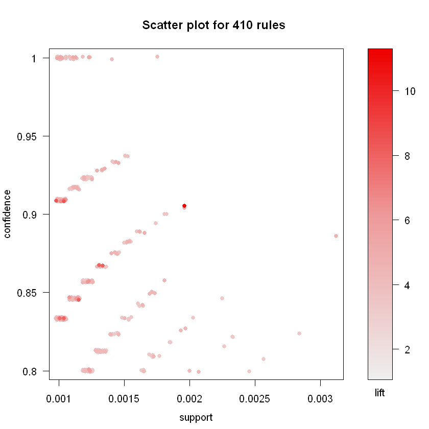

```r
plot(regras, control=list(jitter=2))
```

```r
regras_high_lift <- head(sort(regras, by="lift"), 3)
```

```r
inspect(regras_high_lift)
```

```
    lhs                        rhs                   support confidence     lift
[1] {liquor,
     red/blush wine}        => {bottled beer}    0.001931876  0.9047619 11.23527
[2] {citrus fruit,
     other vegetables,
     soda,
     fruit/vegetable juice} => {root vegetables} 0.001016777  0.9090909  8.34040
[3] {tropical fruit,
     other vegetables,
     whole milk,
     yogurt,
     oil}                   => {root vegetables} 0.001016777  0.9090909  8.34040
```

**Podemos concluir que 90% dos que levaram {liquor,red/blush wine} também levaram {bottled beer}**

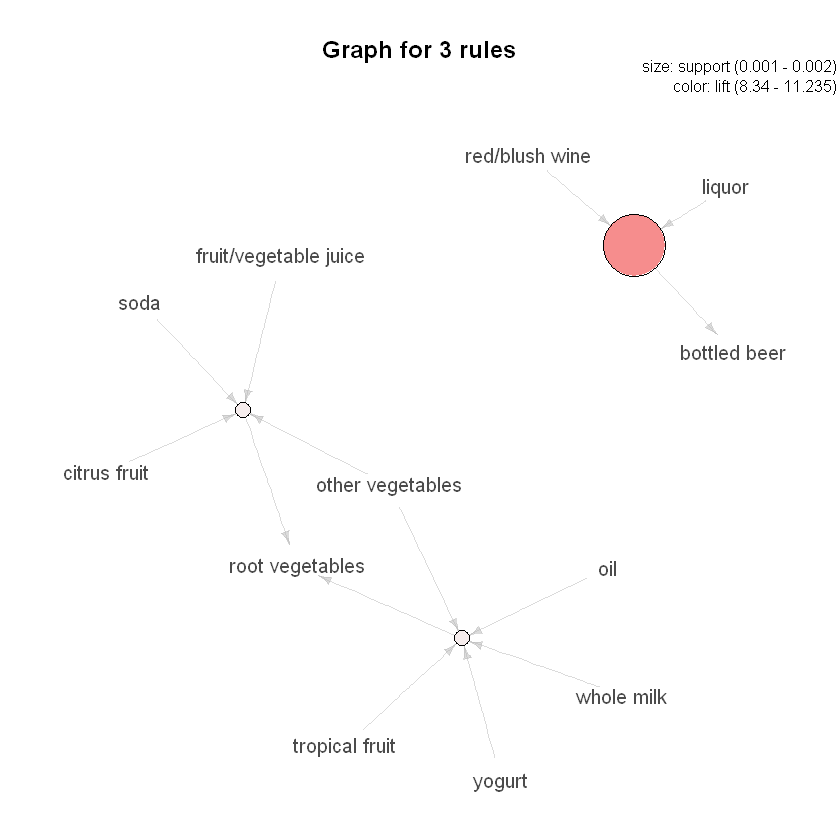

```r
plot(regras_high_lift, method="graph", control=list(type="items"))
```

# Estudo de Caso 4

Este estudo de caso é uma adaptação do excelente trabalho realizado por Flávio Clésio a respeito do uso de Regras de Associação aplicadas na área de Segurança Pública.

**Carregando a Biblioteca "arules"**

```r
library(arules)
```

**Carregando o conjunto de dados. Estes dados por serem sintéticos, podem ter inconsistências**

```r
crimes <- read.csv("https://raw.githubusercontent.com/flaviobrito/dataudit/master/dados/Crimes.csv")
```

**Descrevendo as variáveis**

Temos uma base de dados com 780 crimes com 16 variáveis que são:

- Crime_id: Número da ocorrência.
- Zona: Zona da cidade que a ocorrência foi registrada.
- Periculosidade: Nível de periculosidade da área de acordo com mapeamentos anteriores.
- Viaturas_Apoio_Forca_Tatica: Indica se tem reforços da Força Tática disponíveis na região. A grosso modo, Força Tática é um destacamento que "flutua" na circulação e tem como objetivo atender a ocorrência mais próxima que a primeira força de atendimento não conseguir solucionar.
- Patrulhamento: Indica se há patrulhamento pelas viaturas do batalhão mais próximo.
- Policiamento_Ostensivo: Informa se há operações acontecendo com mais frequência. Um maior nível de policiamento aumenta também o enfrentamento policial, o que pode acarretar em mais óbitos de ambas as partes.
- Apoio_GCM: Esse campo indica se a Guarda Civil Metropolitana circula na área da ocorrência. Diferente da PM ou da Civil; a GCM apesar das mesmas prerrogativas policiais tem uma função mais voltada à segurança patrimonial de alguns pontos da cidade e escolas.
- Arma_Fogo: Houve arma de fogo na ocorrência.
- Qtde_Vitimas: Número de vitimas da ocorrência.
- Possui_DP: Tem Distrito Policial nas redondezas.
- Tipo_Policiamento: O tipo de policiamento local influencia também na prática de crimes, em que áreas menos assistidas pelos batalhões podem ter um maior índice de violência em relação à áreas que não tem esse tipo de atendimento com um maior volume de viaturas e policiais.
- Area_Residencial: Indica se é área residencial ou não.
- Ocorrencia_Atendida_15_Minutos: Sabe-se que quanto mais demorado for o atendimento da ocorrência, as chances de resolução do evento criminoso em questão converge para a não solução efetiva. Esse campo indica se a ocorrência foi prontamente atendida.
- Pericia: Informa se houve a perícia para auxiliar nas investigações.
- Possui_UPP: Mostra se tem Unidade de Polícia Pacificadora instalada nas redondezas do evento criminoso
- Iluminacao: Informa se o local do crime tinha iluminação ou não.

**Examinando a estrutura do conjunto de dados**

```r
str(crimes)
```

```
'data.frame':	780 obs. of  16 variables:
 $ Crime_id                      : Factor w/ 780 levels "crime_1","crime_10",..: 1 112 223 334 445 556 667 759 770 2 ...
 $ Zona                          : Factor w/ 5 levels "Centro","Zona_Leste",..: 5 5 5 5 5 5 5 5 5 5 ...
 $ Periculosidade                : Factor w/ 5 levels "Altissimo","Baixissimo",..: 1 1 1 1 1 1 1 1 2 1 ...
 $ Viaturas_Apoio_Forca_Tatica   : Factor w/ 6 levels "0","1","2","3",..: 5 6 5 3 4 2 4 2 6 4 ...
 $ Patrulhamento                 : Factor w/ 2 levels "Nao","Sim": 2 2 2 2 2 1 2 2 2 2 ...
 $ Policiamento_Ostensivo        : Factor w/ 2 levels "Nao","Sim": 2 2 2 2 2 1 2 2 2 2 ...
 $ Apoio_GCM                     : Factor w/ 2 levels "Nao","Sim": 1 1 1 1 1 1 1 2 1 1 ...
 $ Arma_Fogo                     : Factor w/ 2 levels "Nao","Sim": 1 2 2 2 2 2 2 2 2 2 ...
 $ Qtde_Vitimas                  : Factor w/ 8 levels "0","1","2","3",..: 5 6 4 3 5 4 4 4 6 4 ...
 $ Possui_DP                     : Factor w/ 3 levels "DP_12_Horas",..: 3 2 3 3 3 1 3 3 3 3 ...
 $ Tipo_Policiamento             : Factor w/ 6 levels "Batalhao_Dedicado",..: 3 5 1 3 5 4 4 1 5 1 ...
 $ Area_Residencial              : Factor w/ 2 levels "Nao","Sim": 1 2 2 2 2 1 2 2 2 2 ...
 $ Ocorrencia_Atendida_15_Minutos: Factor w/ 2 levels "Nao","Sim": 1 2 2 2 1 1 2 1 2 2 ...
 $ Pericia                       : Factor w/ 2 levels "Nao","Sim": 1 1 1 2 1 2 1 2 2 2 ...
 $ Possui_UPP                    : Factor w/ 2 levels "Nao","Sim": 2 1 2 2 1 1 1 2 2 2 ...
 $ Iluminacao                    : Factor w/ 2 levels "Nao","Sim": 2 2 2 2 2 1 2 2 2 2 ...
```

**Resumo estatístico**

```r
summary(crimes)
```

```
      Crime_id            Zona        Periculosidade
 crime_1  :  1   Centro     : 23   Altissimo :421
 crime_10 :  1   Zona_Leste : 19   Baixissimo: 96
 crime_100:  1   Zona_Naorte: 44   Baixo     : 94
 crime_101:  1   Zona_Oeste : 28   Medio     : 59
 crime_102:  1   Zona_Sul   :666   Neutro    :110
 crime_103:  1
 (Other)  :774
 Viaturas_Apoio_Forca_Tatica Patrulhamento Policiamento_Ostensivo Apoio_GCM
 0 :  7                      Nao: 80       Nao:133                Nao:576
 1 :115                      Sim:700       Sim:647                Sim:204
 2 :153
 3 :154
 4 :123
 5+:228

 Arma_Fogo  Qtde_Vitimas       Possui_DP
 Nao:278   5+     :230   DP_12_Horas: 58
 Sim:502   3      :214   Nao        :240
           2      :161   Sim        :482
           4      : 89
           1      : 68
           Sim    :  8
           (Other): 10
                        Tipo_Policiamento Area_Residencial
 Batalhao_Dedicado               :229     Nao:118
 Nao                             :  8     Sim:662
 Patrulhamento_Batalhoes_Diversos:382
 Policia_Comunitaria_Escolar     : 97
 Policiamento_via_Companhia      : 60
 Sim                             :  4

 Ocorrencia_Atendida_15_Minutos Pericia   Possui_UPP Iluminacao
 Nao:195                        Nao:397   Nao:352    Nao: 95
 Sim:585                        Sim:383   Sim:428    Sim:685
```

**No mundo real nem sempre torna-se fácil aumentar o valor de confiança e ter também um bom valor de suporte. Este é o desejável. Nosso primeiro movimento é trabalhar para conseguir regras com algum senso próximo a realidade. Descartaremos as regras furadas.**

```r
crimes_rulez <- apriori(crimes, parameter = list(minlen=4,maxlen=10, supp=0.55, conf=0.80))
```

```
Apriori

Parameter specification:
 confidence minval smax arem  aval originalSupport maxtime support minlen
        0.8    0.1    1 none FALSE            TRUE       5    0.55      4
 maxlen target   ext
     10  rules FALSE

Algorithmic control:
 filter tree heap memopt load sort verbose
    0.1 TRUE TRUE  FALSE TRUE    2    TRUE

Absolute minimum support count: 429

set item appearances ...[0 item(s)] done [0.00s].
set transactions ...[831 item(s), 780 transaction(s)] done [0.00s].
sorting and recoding items ... [9 item(s)] done [0.00s].
creating transaction tree ... done [0.00s].
checking subsets of size 1 2 3 4 5 done [0.00s].
writing ... [66 rule(s)] done [0.00s].
creating S4 object  ... done [0.00s].
```

**Reduzindo o número de dígitos nas medidas de qualidade do modelo.**

```r
quality(crimes_rulez) <- round(quality(crimes_rulez), digits=2)
```

**Ordenando pela Confiança, Suporte e Lift**

```r
model_srt_confidence <- sort(crimes_rulez, by="confidence")

model_srt_support <- sort(crimes_rulez, by="support")

model_srt_lift <- sort(crimes_rulez, by="lift")
```

**Verificando o Modelo**

```r
inspect(model_srt_confidence[1:4])
```

```
    lhs                                     rhs                 support confidence lift
[1] {Apoio_GCM=Nao,
     Area_Residencial=Sim,
     Iluminacao=Sim}                     => {Patrulhamento=Sim}    0.57       0.98 1.09
[2] {Policiamento_Ostensivo=Sim,
     Area_Residencial=Sim,
     Ocorrencia_Atendida_15_Minutos=Sim} => {Iluminacao=Sim}       0.61       0.96 1.09
[3] {Policiamento_Ostensivo=Sim,
     Area_Residencial=Sim,
     Ocorrencia_Atendida_15_Minutos=Sim} => {Patrulhamento=Sim}    0.60       0.96 1.06
[4] {Zona=Zona_Sul,
     Policiamento_Ostensivo=Sim,
     Ocorrencia_Atendida_15_Minutos=Sim} => {Iluminacao=Sim}       0.56       0.96 1.09
```

```r
inspect(model_srt_support[1:4])
```

```
    lhs                             rhs                          support confidence lift
[1] {Policiamento_Ostensivo=Sim,
     Area_Residencial=Sim,
     Iluminacao=Sim}             => {Patrulhamento=Sim}             0.69       0.96 1.07
[2] {Patrulhamento=Sim,
     Policiamento_Ostensivo=Sim,
     Area_Residencial=Sim}       => {Iluminacao=Sim}                0.69       0.95 1.08
[3] {Patrulhamento=Sim,
     Policiamento_Ostensivo=Sim,
     Iluminacao=Sim}             => {Area_Residencial=Sim}          0.69       0.93 1.09
[4] {Patrulhamento=Sim,
     Area_Residencial=Sim,
     Iluminacao=Sim}             => {Policiamento_Ostensivo=Sim}    0.69       0.89 1.08
```

```r
inspect(model_srt_lift[1:4])
```

```
    lhs                                     rhs                                  support confidence lift
[1] {Zona=Zona_Sul,
     Ocorrencia_Atendida_15_Minutos=Sim,
     Iluminacao=Sim}                     => {Policiamento_Ostensivo=Sim}            0.56       0.94 1.14
[2] {Zona=Zona_Sul,
     Patrulhamento=Sim,
     Ocorrencia_Atendida_15_Minutos=Sim} => {Policiamento_Ostensivo=Sim}            0.55       0.94 1.14
[3] {Policiamento_Ostensivo=Sim,
     Area_Residencial=Sim,
     Iluminacao=Sim}                     => {Ocorrencia_Atendida_15_Minutos=Sim}    0.61       0.84 1.12
[4] {Zona=Zona_Sul,
     Area_Residencial=Sim,
     Iluminacao=Sim}                     => {Policiamento_Ostensivo=Sim}            0.64       0.93 1.12
```

```r
inspect(crimes_rulez[1:4])
```

```
    lhs                                     rhs                    support confidence lift
[1] {Apoio_GCM=Nao,
     Area_Residencial=Sim,
     Iluminacao=Sim}                     => {Patrulhamento=Sim}       0.57       0.98 1.09
[2] {Patrulhamento=Sim,
     Apoio_GCM=Nao,
     Area_Residencial=Sim}               => {Iluminacao=Sim}          0.57       0.95 1.08
[3] {Patrulhamento=Sim,
     Apoio_GCM=Nao,
     Iluminacao=Sim}                     => {Area_Residencial=Sim}    0.57       0.92 1.08
[4] {Policiamento_Ostensivo=Sim,
     Area_Residencial=Sim,
     Ocorrencia_Atendida_15_Minutos=Sim} => {Iluminacao=Sim}          0.61       0.96 1.09
```

```r
inspect(model_srt_confidence[1:4])
```

```
    lhs                                     rhs                 support confidence lift
[1] {Apoio_GCM=Nao,
     Area_Residencial=Sim,
     Iluminacao=Sim}                     => {Patrulhamento=Sim}    0.57       0.98 1.09
[2] {Policiamento_Ostensivo=Sim,
     Area_Residencial=Sim,
     Ocorrencia_Atendida_15_Minutos=Sim} => {Iluminacao=Sim}       0.61       0.96 1.09
[3] {Policiamento_Ostensivo=Sim,
     Area_Residencial=Sim,
     Ocorrencia_Atendida_15_Minutos=Sim} => {Patrulhamento=Sim}    0.60       0.96 1.06
[4] {Zona=Zona_Sul,
     Policiamento_Ostensivo=Sim,
     Ocorrencia_Atendida_15_Minutos=Sim} => {Iluminacao=Sim}       0.56       0.96 1.09
```

```r
inspect(model_srt_support[1:10])
```

```
     lhs                             rhs                          support confidence lift
[1]  {Policiamento_Ostensivo=Sim,
      Area_Residencial=Sim,
      Iluminacao=Sim}             => {Patrulhamento=Sim}             0.69       0.96 1.07
[2]  {Patrulhamento=Sim,
      Policiamento_Ostensivo=Sim,
      Area_Residencial=Sim}       => {Iluminacao=Sim}                0.69       0.95 1.08
[3]  {Patrulhamento=Sim,
      Policiamento_Ostensivo=Sim,
      Iluminacao=Sim}             => {Area_Residencial=Sim}          0.69       0.93 1.09
[4]  {Patrulhamento=Sim,
      Area_Residencial=Sim,
      Iluminacao=Sim}             => {Policiamento_Ostensivo=Sim}    0.69       0.89 1.08
[5]  {Zona=Zona_Sul,
      Policiamento_Ostensivo=Sim,
      Iluminacao=Sim}             => {Patrulhamento=Sim}             0.66       0.95 1.06
[6]  {Zona=Zona_Sul,
      Patrulhamento=Sim,
      Policiamento_Ostensivo=Sim} => {Iluminacao=Sim}                0.66       0.94 1.08
[7]  {Patrulhamento=Sim,
      Policiamento_Ostensivo=Sim,
      Iluminacao=Sim}             => {Zona=Zona_Sul}                 0.66       0.88 1.03
[8]  {Zona=Zona_Sul,
      Patrulhamento=Sim,
      Iluminacao=Sim}             => {Policiamento_Ostensivo=Sim}    0.66       0.92 1.11
[9]  {Zona=Zona_Sul,
      Area_Residencial=Sim,
      Iluminacao=Sim}             => {Patrulhamento=Sim}             0.66       0.96 1.06
[10] {Zona=Zona_Sul,
      Patrulhamento=Sim,
      Area_Residencial=Sim}       => {Iluminacao=Sim}                0.66       0.95 1.08
```

```r
inspect(model_srt_lift[1:10])
```

```
     lhs                                     rhs                                  support confidence lift
[1]  {Zona=Zona_Sul,
      Ocorrencia_Atendida_15_Minutos=Sim,
      Iluminacao=Sim}                     => {Policiamento_Ostensivo=Sim}            0.56       0.94 1.14
[2]  {Zona=Zona_Sul,
      Patrulhamento=Sim,
      Ocorrencia_Atendida_15_Minutos=Sim} => {Policiamento_Ostensivo=Sim}            0.55       0.94 1.14
[3]  {Policiamento_Ostensivo=Sim,
      Area_Residencial=Sim,
      Iluminacao=Sim}                     => {Ocorrencia_Atendida_15_Minutos=Sim}    0.61       0.84 1.12
[4]  {Zona=Zona_Sul,
      Area_Residencial=Sim,
      Iluminacao=Sim}                     => {Policiamento_Ostensivo=Sim}            0.64       0.93 1.12
[5]  {Zona=Zona_Sul,
      Patrulhamento=Sim,
      Area_Residencial=Sim}               => {Policiamento_Ostensivo=Sim}            0.64       0.93 1.12
[6]  {Zona=Zona_Sul,
      Patrulhamento=Sim,
      Area_Residencial=Sim,
      Iluminacao=Sim}                     => {Policiamento_Ostensivo=Sim}            0.61       0.93 1.12
[7]  {Patrulhamento=Sim,
      Policiamento_Ostensivo=Sim,
      Area_Residencial=Sim}               => {Ocorrencia_Atendida_15_Minutos=Sim}    0.60       0.83 1.11
[8]  {Zona=Zona_Sul,
      Patrulhamento=Sim,
      Ocorrencia_Atendida_15_Minutos=Sim} => {Area_Residencial=Sim}                  0.55       0.94 1.11
[9]  {Patrulhamento=Sim,
      Ocorrencia_Atendida_15_Minutos=Sim,
      Iluminacao=Sim}                     => {Area_Residencial=Sim}                  0.65       0.94 1.11
[10] {Patrulhamento=Sim,
      Area_Residencial=Sim,
      Iluminacao=Sim}                     => {Ocorrencia_Atendida_15_Minutos=Sim}    0.65       0.83 1.11
```

**Criando regras específicas mineradas.**

```r
Zona_Sul <- subset(crimes_rulez, subset = rhs %pin% "Zona=Zona_Sul")



Iluminacao_Sim <- subset(crimes_rulez, subset = rhs %pin% "Iluminacao=Sim")



Ocorrencia_Atendida_15_Minutos_Sim <- subset(crimes_rulez, subset = rhs %pin% "Ocorrencia_Atendida_15_Minutos=Sim")



Policiamento_Ostensivo <- subset(crimes_rulez, subset = rhs %pin% "Policiamento_Ostensivo=Sim")
```

**Regras Específicas**

```r
inspect(Zona_Sul[1:4])
```

```
    lhs                                     rhs             support confidence lift
[1] {Policiamento_Ostensivo=Sim,
     Ocorrencia_Atendida_15_Minutos=Sim,
     Iluminacao=Sim}                     => {Zona=Zona_Sul}    0.56       0.87 1.01
[2] {Patrulhamento=Sim,
     Policiamento_Ostensivo=Sim,
     Ocorrencia_Atendida_15_Minutos=Sim} => {Zona=Zona_Sul}    0.55       0.86 1.01
[3] {Area_Residencial=Sim,
     Ocorrencia_Atendida_15_Minutos=Sim,
     Iluminacao=Sim}                     => {Zona=Zona_Sul}    0.55       0.82 0.96
[4] {Patrulhamento=Sim,
     Area_Residencial=Sim,
     Ocorrencia_Atendida_15_Minutos=Sim} => {Zona=Zona_Sul}    0.55       0.82 0.96
```

```r
inspect(Iluminacao_Sim[1:4])
```

```
    lhs                                     rhs              support confidence lift
[1] {Patrulhamento=Sim,
     Apoio_GCM=Nao,
     Area_Residencial=Sim}               => {Iluminacao=Sim}    0.57       0.95 1.08
[2] {Policiamento_Ostensivo=Sim,
     Area_Residencial=Sim,
     Ocorrencia_Atendida_15_Minutos=Sim} => {Iluminacao=Sim}    0.61       0.96 1.09
[3] {Zona=Zona_Sul,
     Policiamento_Ostensivo=Sim,
     Ocorrencia_Atendida_15_Minutos=Sim} => {Iluminacao=Sim}    0.56       0.96 1.09
[4] {Patrulhamento=Sim,
     Policiamento_Ostensivo=Sim,
     Ocorrencia_Atendida_15_Minutos=Sim} => {Iluminacao=Sim}    0.62       0.95 1.09
```

```r
inspect(Ocorrencia_Atendida_15_Minutos_Sim[1:4])
```

```
    lhs                             rhs                                  support confidence lift
[1] {Policiamento_Ostensivo=Sim,
     Area_Residencial=Sim,
     Iluminacao=Sim}             => {Ocorrencia_Atendida_15_Minutos=Sim}    0.61       0.84 1.12
[2] {Patrulhamento=Sim,
     Policiamento_Ostensivo=Sim,
     Area_Residencial=Sim}       => {Ocorrencia_Atendida_15_Minutos=Sim}    0.60       0.83 1.11
[3] {Zona=Zona_Sul,
     Policiamento_Ostensivo=Sim,
     Iluminacao=Sim}             => {Ocorrencia_Atendida_15_Minutos=Sim}    0.56       0.82 1.09
[4] {Patrulhamento=Sim,
     Policiamento_Ostensivo=Sim,
     Iluminacao=Sim}             => {Ocorrencia_Atendida_15_Minutos=Sim}    0.62       0.82 1.10
```

```r
inspect(Policiamento_Ostensivo[1:4])
```

```
    lhs                                     rhs                          support confidence lift
[1] {Area_Residencial=Sim,
     Ocorrencia_Atendida_15_Minutos=Sim,
     Iluminacao=Sim}                     => {Policiamento_Ostensivo=Sim}    0.61       0.90 1.08
[2] {Patrulhamento=Sim,
     Area_Residencial=Sim,
     Ocorrencia_Atendida_15_Minutos=Sim} => {Policiamento_Ostensivo=Sim}    0.60       0.90 1.08
[3] {Zona=Zona_Sul,
     Ocorrencia_Atendida_15_Minutos=Sim,
     Iluminacao=Sim}                     => {Policiamento_Ostensivo=Sim}    0.56       0.94 1.14
[4] {Zona=Zona_Sul,
     Patrulhamento=Sim,
     Ocorrencia_Atendida_15_Minutos=Sim} => {Policiamento_Ostensivo=Sim}    0.55       0.94 1.14
```

**Mais regras para exportação**

```r
crimes_rulez_2 <- apriori(crimes, parameter = list(minlen=4,maxlen=20, supp=0.4, conf=0.90))
```

```
Apriori

Parameter specification:
 confidence minval smax arem  aval originalSupport maxtime support minlen
        0.9    0.1    1 none FALSE            TRUE       5     0.4      4
 maxlen target   ext
     20  rules FALSE

Algorithmic control:
 filter tree heap memopt load sort verbose
    0.1 TRUE TRUE  FALSE TRUE    2    TRUE

Absolute minimum support count: 312

set item appearances ...[0 item(s)] done [0.00s].
set transactions ...[831 item(s), 780 transaction(s)] done [0.00s].
sorting and recoding items ... [15 item(s)] done [0.00s].
creating transaction tree ... done [0.00s].
checking subsets of size 1 2 3 4 5 6 done [0.00s].
writing ... [331 rule(s)] done [0.00s].
creating S4 object  ... done [0.00s].
```

**Criando um objeto para dar saída nas informações**

```r
out <- capture.output(inspect(crimes_rulez_2))
```

**Arquivo de saída para as regras**

```r
cat("Regras", out, file="regras.txt", sep="n", append=TRUE)
```

```r
library(arulesViz)
```

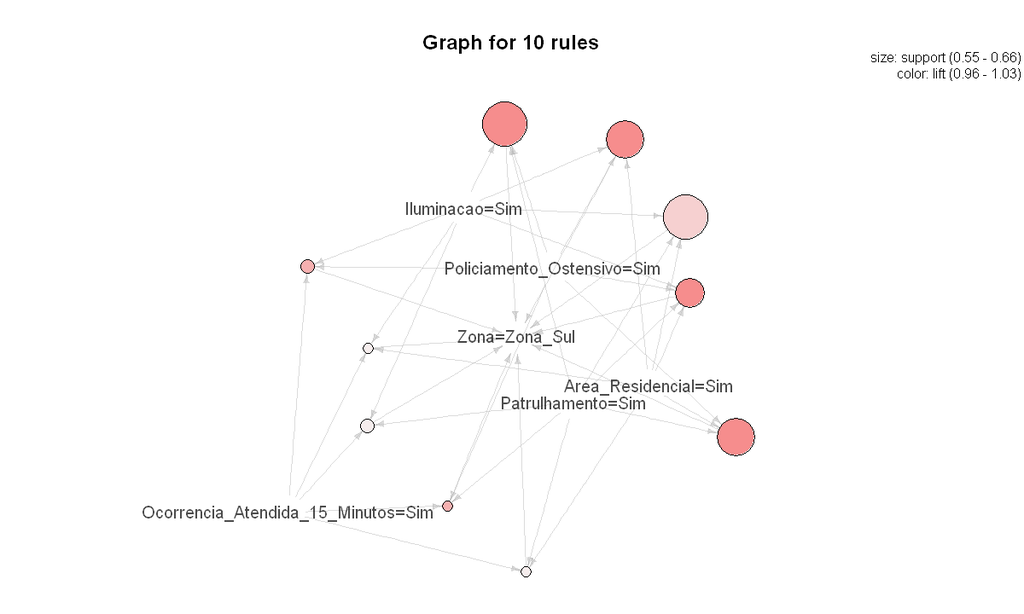

```r
options(repr.plot.width=10, repr.plot.height=6)
plot(Zona_Sul, method="graph", control=list(type="items"))
```